# Projet-3 : Concevez une application au service de la santé publique

[figure not shown]

# Projet-3 : Concevez une application au service de la santé publique

## Introduction

- Traiter le jeu de données afin de repérer des variables pertinentes pour les traitements à venir. Automatiser ces traitements pour éviter de répéter ces opérations.
- **L'idée de l'application** : aide à l'identification des produits à surveiller dans le cas de régime alimentaire liées à la surveillance en utilisant la base d'OpenFood Facts

## Environnement

```python
import pandas as pd
import numpy as np
import datetime as dt
import sys
import warnings
import IPython as ip
import matplotlib.pyplot as plt
import seaborn as sns
from IPython.display import display
import missingno as msno
# Configuration pour travail avec fichier python "tools" de fonctions
%load_ext autoreload
%aimport tools

# Set option
pd.set_option('display.max_columns', None)
pd.set_option('display.max_rows', None)

# Recharger les modules pour la conception des fichiers tools

%autoreload 1

warnings.filterwarnings("ignore")
```

# 1. Chargement des données

```python
# Import données
data = pd.read_csv('assets/datas/openfoodfacts.csv', sep='\t', low_memory=False)
```

# 2. Nettoyage du jeu de données

```python
# Afficher le nombre de lignes de colonnes et de doublon je de données initial
tools.get_info_data(data,doublon=True)
```

```
------------------------------------------------------------------
Taille du jeu de données

Nombre de lignes : 320772 lignes
Nombre de colonnes : 162 colonnes
Nombre d'éléments dupliqués dans le dataframe : 0 eléments
------------------------------------------------------------------
```

```python
# Afficher les 3 premières lignes du jeu de données
data.head(3)
```

|  | code | url | creator | created_t | created_datetime | last_modified_t | last_modified_datetime | product_name | generic_name | quantity | packaging | packaging_tags | brands | brands_tags | categories | categories_tags | categories_fr | origins | origins_tags | manufacturing_places | manufacturing_places_tags | labels | labels_tags | labels_fr | emb_codes | emb_codes_tags | first_packaging_code_geo | cities | cities_tags | … |
| --- | --- | --- | --- | --- | --- | --- | --- | --- | --- | --- | --- | --- | --- | --- | --- | --- | --- | --- | --- | --- | --- | --- | --- | --- | --- | --- | --- | --- | --- | --- |
| 0 | 0000000003087 | http://world-fr.openfoodfacts.org/produit/0000... | openfoodfacts-contributors | 1474103866 | 2016-09-17T09:17:46Z | 1474103893 | 2016-09-17T09:18:13Z | Farine de blé noir | NaN | 1kg | NaN | NaN | Ferme t'y R'nao | ferme-t-y-r-nao | NaN | NaN | NaN | NaN | NaN | NaN | NaN | NaN | NaN | NaN | NaN | NaN | NaN | NaN | NaN | … |
| 1 | 0000000004530 | http://world-fr.openfoodfacts.org/produit/0000... | usda-ndb-import | 1489069957 | 2017-03-09T14:32:37Z | 1489069957 | 2017-03-09T14:32:37Z | Banana Chips Sweetened (Whole) | NaN | NaN | NaN | NaN | NaN | NaN | NaN | NaN | NaN | NaN | NaN | NaN | NaN | NaN | NaN | NaN | NaN | NaN | NaN | NaN | NaN | … |
| 2 | 0000000004559 | http://world-fr.openfoodfacts.org/produit/0000... | usda-ndb-import | 1489069957 | 2017-03-09T14:32:37Z | 1489069957 | 2017-03-09T14:32:37Z | Peanuts | NaN | NaN | NaN | NaN | Torn & Glasser | torn-glasser | NaN | NaN | NaN | NaN | NaN | NaN | NaN | NaN | NaN | NaN | NaN | NaN | NaN | NaN | NaN | … |

```python
# Création d'un df de travail
df = data.copy()
```

### 2.1 Nettoyage des types

```
-------------------------------------------------------------
Type de variable pour chacune des variables
```

```
code                                           object
url                                            object
creator                                        object
created_t                                      object
created_datetime                               object
last_modified_t                                object
last_modified_datetime                         object
product_name                                   object
generic_name                                   object
quantity                                       object
packaging                                      object
packaging_tags                                 object
brands                                         object
brands_tags                                    object
categories                                     object
categories_tags                                object
categories_fr                                  object
origins                                        object
origins_tags                                   object
manufacturing_places                           object
manufacturing_places_tags                      object
labels                                         object
labels_tags                                    object
labels_fr                                      object
emb_codes                                      object
emb_codes_tags                                 object
first_packaging_code_geo                       object
cities                                         object
cities_tags                                    object
purchase_places                                object
stores                                         object
countries                                      object
countries_tags                                 object
countries_fr                                   object
ingredients_text                               object
allergens                                      object
allergens_fr                                   object
traces                                         object
traces_tags                                    object
traces_fr                                      object
```

[output cut: 108 more lines]

```
molybdenum_100g                               float64
iodine_100g                                   float64
caffeine_100g                                 float64
taurine_100g                                  float64
ph_100g                                       float64
fruits-vegetables-nuts_100g                   float64
collagen-meat-protein-ratio_100g              float64
cocoa_100g                                    float64
chlorophyl_100g                               float64
carbon-footprint_100g                         float64
nutrition-score-fr_100g                       float64
nutrition-score-uk_100g                       float64
glycemic-index_100g                           float64
water-hardness_100g                           float64
dtype: object
```

```
----------------------------------------------------------
Répartition des types de variable
```

|  | Nombre par type de variable | % des types de variable |
| --- | --- | --- |
| float64 | 106 | 65.430000 |
| object | 56 | 34.570000 |

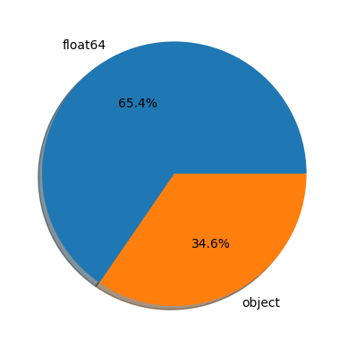

```python
tools.get_types_variables(df,True,True,True)
```

**Erreurs de formattage** :

- On convertie 'created_datetime','last_modified_datetime' en date

**Erreurs lexicales** : dans les colonnes 'created_datetime','last_modified_datetime

- On supprime les erreurs en les remplaçant par NaN

```python
liste_erreur_a_supprimer_date=['en:belgium,en:france',
                               'en:france',
                               'en:belgium,en:france,en:switzerland',
                               'en:france,en:switzerland',
                               'Dia,Sogeres',
                               'SuperU',
                               'Carrefour',
                               'Auchan',
                               'Carrefour market',
                               'SuperU,Leclerc',
                               'Spar',
                               'Banque alimentaire',
                               'Leclerc',
                               'Auchan,Super U',
                               'Super U,Leclerc,Carrefour',
                               'Cora',
                               'Super U',
                               'Super U,Leclerc,Carrefour',
                               'Super U,Leclerc,Carrefour'
                              ]
```

```python
df.loc[df['last_modified_datetime']!=np.number,'last_modified_datetime']='NaN'
df.loc[df['created_datetime']!=np.number,'created_datetime']='NaN'
df.loc[df['created_t']!=np.number,'created_t']='NaN'
df.loc[df['last_modified_t']!=np.number,'last_modified_t']='NaN'

# On convertit la colonne last_modified_dattetime au format date
df["last_modified_datetime"] =  pd.to_datetime(df["last_modified_datetime"], format="%Y-%m-%dT%H:%M:%SZ")
# On convertit la colonne created_datetime au format date
df["created_datetime"] =  pd.to_datetime(df["created_datetime"], format="%Y-%m-%dT%H:%M:%SZ")
df['created_t'] = pd.to_datetime(df['created_t'],unit='s')
df['last_modified_t'] = pd.to_datetime(df['last_modified_t'],unit='s')
```

```python
STOP
```

[output not shown]

```python
# On supprime les erreurs de saisie
# data.loc[data['montant']==-15000, 'montant'] = -14.39
df.loc[df['last_modified_datetime']=='en:belgium,en:france','last_modified_datetime']='NaN'
df.loc[df['last_modified_datetime']=='en:france','last_modified_datetime']='NaN'
df.loc[df['last_modified_datetime']=='en:belgium,en:france,en:switzerland','last_modified_datetime']='NaN'
df.loc[df['last_modified_datetime']=='en:france,en:switzerland','last_modified_datetime']='NaN'

# On convertit la colonne last_modified_dattetime au format date
df["last_modified_datetime"] =  pd.to_datetime(df["last_modified_datetime"], format="%Y-%m-%dT%H:%M:%SZ")
```

```python
# On supprime les erreurs
df.loc[df['created_datetime']=='Dia,Sogeres','created_datetime']='NaN'
df.loc[df['created_datetime']=='SuperU','created_datetime']='NaN'
df.loc[df['created_datetime']=='Carrefour','created_datetime']='NaN'
df.loc[df['created_datetime']=='Auchan','created_datetime']='NaN'
df.loc[df['created_datetime']=='Carrefour market','created_datetime']='NaN'
df.loc[df['created_datetime']=='SuperU,Leclerc','created_datetime']='NaN'
df.loc[df['created_datetime']=='Spar','created_datetime']='NaN'
df.loc[df['created_datetime']=='Banque alimentaire','created_datetime']='NaN'
df.loc[df['created_datetime']=='Leclerc','created_datetime']='NaN'
df.loc[df['created_datetime']=='Auchan,Super U','created_datetime']='NaN'
df.loc[df['created_datetime']=='Super U,Leclerc,Carrefour','created_datetime']='NaN'
df.loc[df['created_datetime']=='Cora','created_datetime']='NaN'
df.loc[df['created_datetime']=='Super U','created_datetime']='NaN'
df.loc[df['created_datetime']=='Super U,Leclerc,Carrefour','created_datetime']='NaN'

# On convertit la colonne created_datetime au format date
df["created_datetime"] =  pd.to_datetime(df["created_datetime"], format="%Y-%m-%dT%H:%M:%SZ")
```

```python
# On supprime les erreurs
df.loc[df['created_t']=='France','created_t']='NaN'
df.loc[df['created_t']=='Villecresnes,Villeurbanne,France','created_t']='NaN'
df.loc[df['created_t']=='Veynes,France','created_t']='NaN'
df.loc[df['created_t']=='Saint-Priest,France','created_t']='NaN'
df.loc[df['created_t']=='Torcy 77,France','created_t']='NaN'
df.loc[df['created_t']=='Villers Bocage 80260,France','created_t']='NaN'
df.loc[df['created_t']=='Montgermont','created_t']='NaN'
df.loc[df['created_t']=='Marseille 5°,France','created_t']='NaN'
df.loc[df['created_t']=='France,Nantes,Carquefou','created_t']='NaN'
df.loc[df['created_t']=='Courrières,France','created_t']='NaN'
df.loc[df['created_t']=='Brétigny-sur-Orge,Marseille 5°','created_t']='NaN'
df.loc[df['created_t']=='Brétigny-sur-Orge,Marseille 5°,France','created_t']='NaN'
df.loc[df['created_t']=='France','created_t']='NaN'

df['created_t'] = pd.to_datetime(df['created_t'],unit='s')
```